This is the git repository for the [DURIN project](https://betweenthefjords.w.uib.no/durin/). The goal of this repo is to organize and streamline the data management in the project and beyond.

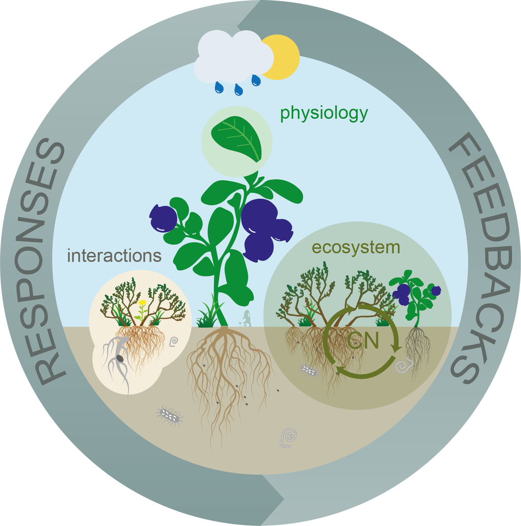

## DATA MANAGEMENT

### Location of data, metadata and code

The overview of all the **datasets** is [here](https://docs.google.com/spreadsheets/d/1KlQwSkcPa09POOSV0B7i_Z5KWcKDyw_Xu7Jikc9voyA/edit?usp=sharing).

The raw and clean **datasets** from are stored and will be made available after the end of the project on [OSF](https://osf.io/f4v9t/). For now the data is only available to the project partners.

All R code for the cleaning the raw data is available on the [Durin GitHub](https://github.com/Durin-project). Code pushed to GitHub should be clean, tested that it does what it is supposed to do and run on any computer (e.g. no absolute path).

The data documentation, including a draft for the data paper is available [here](https://docs.google.com/document/d/13Mky4gZfCzHIZl82zQKX6nb2vRneZXDRVDAmp0a3gdA/edit?usp=sharing) (only available for authors), and the **data dictionaries** are in this below in this readme file.

### Meta data

To help you with the correct naming convention use the function from the dataDocumentation package to create the meta data. Install the dataDocumentation R package like this:

```r
# if needed install the remotes package
install.packages("remotes")

# then install the dataDocumentation package
remotes::install_github("audhalbritter/dataDocumentation")

# and load it
library(dataDocumentation)
```

The function `create_durin_meta_data()` creates meta data. The meta data can be made for the 4Corners, DroughtNet or Nutrient study. Use the argument `study` to define which meta data you want. *4Corners*: study on the 4 main Durin sites; DroughtNet: *droughtNet* experiment at Lygra and Tjotta; *Nutrient*: nutrient experiment at Lygra

```r
my_meta <- create_durin_meta_data(study = "4Corners")
my_meta
```

If you want to save the metadata as a csv file, set csv_output = TRUE and you can choose a file name (not mandatory). The data will be stored in the project directory. The file name always contains Durin and the study, e.g. Durin_4Corners_filename.csv.

```r
create_durin_meta_data(study = "4Corners", csv_output = TRUE, filename = "biomass")
```

### Naming conventions for the clean datasets and files

We use **snake_case** for names and coding. Snake_case means that we use lower case letters separated by an underscore, for example *biomass_g* or *age_class*. The one exception are siteID, blockID, plotID (legacy from previous projects).

**File and variable names should be meaningful**. Do not use *my_data.csv* or *var1*. Follow the naming convention for the main variables (see full description of the main variables in the table below). Note that these naming conventions apply for clean datasets. For field datasheets and raw data, the naming convention does not have to be followed as strictly if other variable facilitate data collection (e.g. splitting date into year, month and day to avoid excel issues).

| File name | Naming convention | Example |
| --- | --- | --- |
| File name | Project_Status_Study_Approach_Response_Year(s).Extension | DURIN_clean_gradient_field_cflux_2023-2025.csv |
|  | Project | DURIN |
|  | Status | raw or clean |
|  | Study | *4Corners*: study on the 4 main Durin sites; *DroughtNet*: droughtNet experiment at Lygra and Tjotta (previously part of Landpress); *Gradient*: gradient study between 4 corners; *Nutrient*: nutrient … |
|  | Approach | field, lab, molecular, other |
|  | Response | trait, biomass, flux, etc. |

We use **redundancy in variable names** to avoid mistakes. PlotID should contain the higher hierarchical levels such as siteID, blockID, treatment, habitat, species etc. For example plotID contains siteID, habitat, species and plot number: LY_O_VV_1, LY_F_VM_3

| Variable name | Naming convention | Example |
| --- | --- | --- |
| **4Corners** |  |  |
| date | Date of data collection | yyyy-mm-dd; do not split year, month and day into several columns |
| year | Year of data collection | yyyy; sometimes there is no specific date, then year can be used |
| site_name | Full site name | Lygra, Sogndal, Senja, Kautokeino and Tjotta |
| siteID | Unique siteID, first 2 letters of site_name. | LY, SO, SE, and KA, TJ |
| biogeography | Biogeography of the site | Boreal, Sub-arctic |
| oceanity | Oceanity of the site | Coast, Inland |
| habitat | Open versus forested habitat | Open, Forested |
| burn_year_original | Last intentional burn year | yyyy; 2010 |
| burn_year_recent | Last accidential burn date | yyyy-mm; 2025-12 |
| plot_nr | Plot number, numeric value from 1-5. | 1-5 |
| plotID | Unique plot ID as a combination of siteID, habitat, speciesID and plot number | LY_O_VV_1, KA_F_VM_5 |
| species | Vascular plant taxon names follow Elven et al. (2022). We use full species names. For field sheets the names can be abbreviated (see speciesID), but the clean data should contain the full species name | *Vaccinium myrtillus* |
| speciesID | 2 letter abbreviation of species | VM, VV, CV, EN, BN |
| plant_nr | Plant number, numeric value | 1-n |
| plantID | plantID is not defined but can be constructed by concatenate siteID, etc. | … |
| segment | S24 = growth in 2024, S23 = growth in 2023, S22 = growth in 2022 | S24, S23, S22 |
| variable | Response variable(s) | e.g. cover, biomass, Reco |
| value | Value of response variable(s) | numeric value |
| unit | Unit for response variable(s) | percent, µmol m−2 s−1 |
| other variables | Other important variables in the dataset | remark, data collector, weather, flag |
| **DroughtNet experiment** |  |  |
| date | Date of data collection | yyyy-mm-dd; do not split year, month and day into several columns |
| year | Year of data collection | yyyy; sometimes there is no specific date, then year can be used |
| site_name | Site name | Lygra, Tjotta |
| siteID | Unique siteID, first 2 letters of site_name. | LY, TJ |
| geography | Location according to latitude | North, South |
| habitat | Open habitat | Open |
| burn_year_original | Last intentional burn year | yyyy; 2010 |
| burn_year_recent | Last accidential burn date | yyyy-mm; 2025-12 |

[output cut: 65 more lines]

Data collections and experiments associated with **plant individuals** and/or **leaves** should have unique IDs for each individual and leaf. PlantID and leafID should contain redundancy of the higher levels, such as siteID, plotID, treatments etc. but also make sure the IDs do not get ridiculously long.

**Data collection might occur outside** of the plots from the studies described above. For those samples include a new variable called *sampling_plot*. The options for this variable are defined (sampling inside a plot) and undefined (sampling outside the plots). The unique ID for these samples will look something like: LY_O_1, SE_F_4

### Organize data sets

Each dataset should **contain only one response variable**, or several if they are closely related. E.g. biomass and carbon flux should be two separate datasets. But the functional trait dataset can contain several traits, and the carbon flux dataset can contain GPP, NEE and Reco.

Datasets should be in a **long format**. If you have several response variables (e.g. traits, flux measurements), then use `pivot_long(cols = ..., names_to = "variable", values_to = "value")` to conver the data to a long format. Using the names *variable* and *value* for the columns is a standard. If you have very different response variables, it can be useful to have a column called *unit*.

When dealing with many different datasets it can be useful to structure them in a similar way. Arrange the dataset so that the important variables come first, preferable use this order:

- Year and/or date
- siteID
- habitat
- treatment
- plotID
- species (focal)
- plantID
- leafID
- response variable, value, unit (diversity, biomass, flux)
- predictor variables (temperature level, oceanity)
- other_variables (remark, data collector, weather)

### Data dictionary

**How to make a data dictionary?**

The R package **dataDocumentation** that will help you to make the data dictionary. You can install and load the package as follows:

```r
# if needed install the remotes package
install.packages("remotes")

# then install the dataDocumentation package
remotes::install_github("audhalbritter/dataDocumentation")

# and load it
library(dataDocumentation)
```

*Make data description table*

Find the file *R/data_dic/data_description.xlsx*. Enter all the variables into that table, including variable name, description, unit/treatment level and how measured. If the variables are global for all of Funder, leave TableID blank (e.g. siteID). If the variable is unique for a specific dataset, create a TableID and use it consistently for one specific dataset. Make sure you have described all variables.

*Make data dictionary*

```r
data_dic <- make_data_dictionary(data = biomass,
                                 description_table = description_table,
                                 table_ID = "biomass",
                                 keep_table_ID = FALSE)
```

Check that the function produces the correct data dictionary.

*Add data dictionary to readme file*

Finally, add the data dictionary below to be displayed in this readme file. Add a title, and a code chunk using `kable()` to display the data dictionary.

For more details go to the [dataDocumentation readme](https://github.com/audhalbritter/dataDocumentation) file.

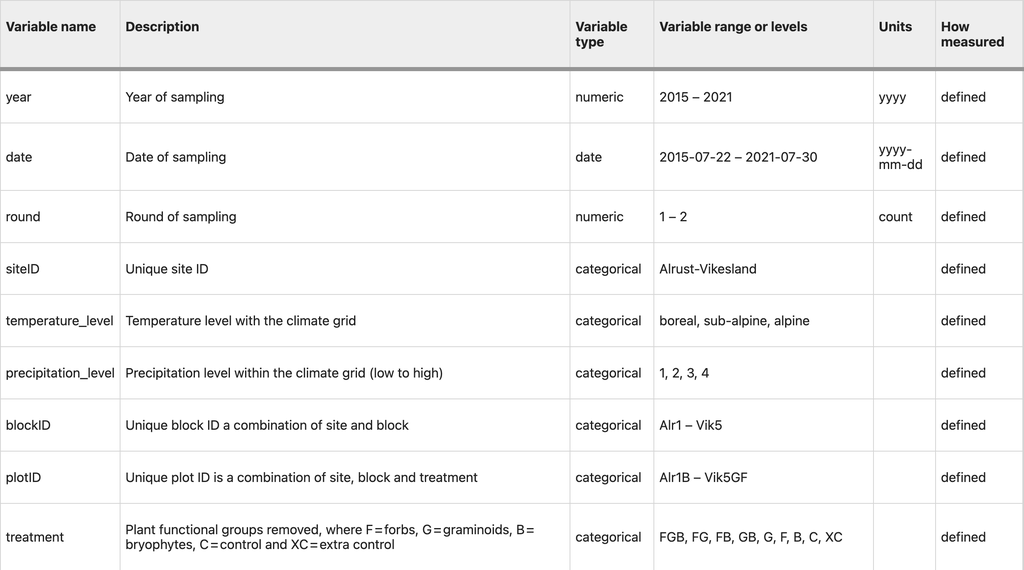